# UX of AI

User Experience of Artificial Intelligence

## Background

"Machine Learning" is becoming just another tool in a developers toolbox.

PyTorch and TensorFlow compete with React as most loved tool by 70% of devs

<sub>* From [StackOverflow's 2018 survey](https://insights.stackoverflow.com/survey/2018/)</sub>

72.8% say "I'm excited about the possibilities more than worried about the dangers."

<sub>* From [StackOverflow's 2018 survey](https://insights.stackoverflow.com/survey/2018/)</sub>

47.8% say "The developers or the people creating the AI" are primarily responsible for ML ramifications

<sub>* From [StackOverflow's 2018 survey](https://insights.stackoverflow.com/survey/2018/)</sub>

People are hyped about fairness.

*(or at least upset about their super racist smart couch)*

[figure not shown]

Moritz Hardt (@mrtz), UC Berkeley, Fall 2017

NeurIPS 2018

- workshop on ["Ethical, Social and Governance Issues in AI"](https://nips.cc/Conferences/2018/Schedule?showEvent=10940)

NeurIPS 2018

- tutorial on ["Common Pitfalls for Studying the Human Side of Machine Learning"](https://nips.cc/Conferences/2018/Schedule?showEvent=10981)

NeurIPS 2018

- invited talks on [Algorithmic Bias](https://nips.cc/Conferences/2018/Schedule?showEvent=12870), [Public Policy](https://nips.cc/Conferences/2018/Schedule?showEvent=12483) and ["Human-AI Trust"](https://nips.cc/Conferences/2018/Schedule?showEvent=12301)

Google's UX team

- ["Human-Centered Machine Learning"](https://medium.com/google-design/human-centered-machine-learning-a770d10562cd) to guide conversations

Google's UX team

- Great publications on [UX of AI](https://design.google/library/ux-ai/) from which I shamelessly stole the title

People want to know what the heck the deep nets are doing.

*(myself included, if you find out tell me)*

[figure not shown]

<sub>@karpathy's lossfunctions.tumblr.com</sub>

[figure not shown]

<sub>https://ganbreeder.app</sub>

## Overview

- Interpretability and Explainability
  - background
  - Implicitly interpretable models
  - Review of model agnostic methods
  - Example based explanations

## Overview

- Interpretability and Explainability
- Ethical considerations
  - Fairness
  - Privacy
  - Trust

## Overview

- Interpretability and Explainability
- Ethical considerations
- Design with AI
  - Human centered AI
  - UX of AI

## Interpretability and Explainability

[figure not shown]

<sub>Oralytics Blog, **2012**</sub>

[figure not shown]

<sub><sub>I think we can agree</sub></sub></sub>

Whatever `'data science'` is,

it has `science` in the name

From David J. Spiegelhalter, Royal Society. "Science as an Open Enterprise." (**2012**)

"Realising the benefits of open data requires effective communication through a more intelligent openness ..."

<sub>-David J. Spiegelhalter, Royal Society (**2012**).</sub>

"... data must be **accessible** and readily located ..."

<sub>-David J. Spiegelhalter, Royal Society (**2012**).</sub>

" ... they must be **intelligible** to those who wish to scrutinise them ..."

<sub>-David J. Spiegelhalter, Royal Society (**2012**).</sub>

"...data must be **assessable** so that judgments can be made about their reliability and the competence of those who created them;..."

<sub>-David J. Spiegelhalter (**2012**).</sub>

<sub><sub>please don't check my commit history</sub></sub></sub>

" ...and they must be **usable** by others. "

<sub>-David J. Spiegelhalter (**2012**).</sub>

Users of your data or your model have a right to an explanation<sup>[1](https://en.wikipedia.org/wiki/Right_to_explanation)</sup>

This is the law in contexts like:

- credit scores in the United States ([ECOA](https://www.law.cornell.edu/uscode/text/15/chapter-41/subchapter-IV))
- general data in the EU ([GDPR](https://eur-lex.europa.eu/legal-content/EN/TXT/?qid=1528874672298&uri=CELEX%3A32016R0679))

Christoph Molnar has a great book on this from which I got most of this material:

["Interpretable Machine Learning: A Guide for Making Black Box Models Explainable"](https://christophm.github.io/interpretable-ml-book/index.html)

## Interpretability vs explainability

**Interpretability** - "*What* is in this model, *how* does it treat input"

**Explainability** - "*Why* did this model do that this time"

Sometimes you get neither

[figure not shown]

Sometimes you get both

**Interpretability**

`ganbreeder.app` provides links to [BigGAN model info / exploration on tfhub](https://tfhub.dev/deepmind/biggan-128/2)

**Explainability**

[figure not shown]

Here are some principles for providing good interpretation and explanation ...

**Interpretation/Explanation methods should be**

- *Portable* to other models
- *Expressive* in presentation
- *Translucent* in relying on model internals
- *Low in Algorithmic Complexity*

**Individual interpretation / explanations should have**

- *Accuracy* similar to model output (correctness)
- *Fidelity* in approximation of model (resolution)
- *Consistency* between models
- *Stability* between prediction instances ...

(...continued)

- *Comprehensibility* for humans
- *Certainty* for impact assessment
- *Importance* for parts of explanation
- *Measure of Novelty* of prediction instance
- *Representativeness* in instance coverage

These are generally properties of related algorithms, but they also apply to UX of AI

## Implicitly interpretable models

Some models are interpretable and explainable by default.

[figure not shown]

If you can use a heuristic **do it**

If you can't, use

- a decision tree
- linear (or logistic) regression
- Generalized Linear (or Additive) Models
- naive Bayes
- nearest neighbours

[figure not shown]

## Example based explanations

### Counterfactual Explanations

A causal explanation:

`If X had not occurred, Y would not have occurred`

`If I hadn’t taken a sip of this hot coffee, I wouldn’t have burned my tongue`

`If your 2-hour serum insulin level was 154.3, you would have a score of 0.51`

```
If you don't eat yer meat, you can't have any pudding
How can you have any pudding if you don't eat yer meat?
```

Pros

- Clear
- Doesn't require access to model / data, just prediction
- Works with non-ML systems
- Basically a loss function, fairly simple to implement

Cons

- Rashomon effect: you can have multiple matching explanations
- No guarantee an explanation instance can be found
- Lacks a general software solution

Growing Spheres algorithm

1. Make a sphere around your prediction in the latent space
2. Grab a sample outside, see if it's different
3. Make it bigger until the stuff you're grabbing is different

[figure not shown]

<sub>Growing Spheres algorithm by Laugel et. al (2017)</sub>

Or use 'Anchor' to do the exact opposite.

1. Run 'Growing spheres'
2. Show everything inside the sphere

<sub>Ribeiro et. al (2018).</sub>

[figure not shown]

<sub>[Ribeiro et. al (2018).](https://homes.cs.washington.edu/~marcotcr/aaai18.pdf)</sub>

## Model-Agnostic Methods

The techniques before are model specific.

There are a bunch of methods which work with almost any model.

- Partial Dependence Plot (PDP)
- Individual Conditional Expectation (ICE)
- Accumulated Local Effects (ALE) Plot
- Feature Interaction
- Feature Importance
- Global Surrogate
- Local Surrogate (LIME)
- Shapley Values

## Example

Using [SHAP](https://github.com/slundberg/shap) on a [credit dataset](https://archive.ics.uci.edu/ml/datasets/Statlog+%28German+Credit+Data%29)

#### Data

[UCI German Credit Data](https://archive.ics.uci.edu/ml/datasets/Statlog+%28German+Credit+Data%29)

#### Source

Professor Dr. Hans Hofmann

*University at Hamburg* 1994-11-17

[figure not shown]

Dataset summary:

- 59 columns, 1000 samples
- age, sex, marital status, resident status, employment status, housing
- types of account, credit history, purpose of loan, other bank data
- classifies a person's credit risk

```python
from aif360.datasets import GermanDataset
from german_credit_data_reason_codes import reason_map, display_description
import german_credit_data_reason_codes
from sklearn.model_selection import train_test_split
```

```python
## load data
data = GermanDataset()
X, _ = data.convert_to_dataframe()
X.drop(['credit'], axis=1, inplace=True)
y = data.scores.ravel()
```

```
WARNING:root:'scores' has no well-defined meaning out of range [0, 1].
```

```python
## Split the data for model training / testing
X_train, X_test, y_train, y_test = train_test_split(X,
                                                    y,
                                                    test_size=0.33,
                                                    random_state=42)
```

```python
## Investigate data
X.describe()
# https://pair-code.github.io/facets/index.html#facets-overview
```

|  | month | credit_amount | investment_as_income_percentage | residence_since | age | number_of_credits | people_liable_for | sex | status=A11 | status=A12 | ... | housing=A152 | housing=A153 | skill_level=A171 | skill_level=A172 | skill_level=A173 | skill_level=A174 | telephone=A191 | telephone=A192 | foreign_worker=A201 | foreign_worker=A202 |
| --- | --- | --- | --- | --- | --- | --- | --- | --- | --- | --- | --- | --- | --- | --- | --- | --- | --- | --- | --- | --- | --- |
| count | 1000.000000 | 1000.000000 | 1000.000000 | 1000.000000 | 1000.000000 | 1000.000000 | 1000.000000 | 1000.000000 | 1000.000000 | 1000.000000 | ... | 1000.000000 | 1000.000000 | 1000.000000 | 1000.0000 | 1000.000000 | 1000.000000 | 1000.000000 | 1000.000000 | 1000.000000 | 1000.000000 |
| mean | 20.903000 | 3271.258000 | 2.973000 | 2.845000 | 0.851000 | 1.407000 | 1.155000 | 0.690000 | 0.274000 | 0.269000 | ... | 0.713000 | 0.108000 | 0.022000 | 0.2000 | 0.630000 | 0.148000 | 0.596000 | 0.404000 | 0.963000 | 0.037000 |
| std | 12.058814 | 2822.736876 | 1.118715 | 1.103718 | 0.356267 | 0.577654 | 0.362086 | 0.462725 | 0.446232 | 0.443662 | ... | 0.452588 | 0.310536 | 0.146757 | 0.4002 | 0.483046 | 0.355278 | 0.490943 | 0.490943 | 0.188856 | 0.188856 |
| min | 4.000000 | 250.000000 | 1.000000 | 1.000000 | 0.000000 | 1.000000 | 1.000000 | 0.000000 | 0.000000 | 0.000000 | ... | 0.000000 | 0.000000 | 0.000000 | 0.0000 | 0.000000 | 0.000000 | 0.000000 | 0.000000 | 0.000000 | 0.000000 |
| 25% | 12.000000 | 1365.500000 | 2.000000 | 2.000000 | 1.000000 | 1.000000 | 1.000000 | 0.000000 | 0.000000 | 0.000000 | ... | 0.000000 | 0.000000 | 0.000000 | 0.0000 | 0.000000 | 0.000000 | 0.000000 | 0.000000 | 1.000000 | 0.000000 |
| 50% | 18.000000 | 2319.500000 | 3.000000 | 3.000000 | 1.000000 | 1.000000 | 1.000000 | 1.000000 | 0.000000 | 0.000000 | ... | 1.000000 | 0.000000 | 0.000000 | 0.0000 | 1.000000 | 0.000000 | 1.000000 | 0.000000 | 1.000000 | 0.000000 |
| 75% | 24.000000 | 3972.250000 | 4.000000 | 4.000000 | 1.000000 | 2.000000 | 1.000000 | 1.000000 | 1.000000 | 1.000000 | ... | 1.000000 | 0.000000 | 0.000000 | 0.0000 | 1.000000 | 0.000000 | 1.000000 | 1.000000 | 1.000000 | 0.000000 |
| max | 72.000000 | 18424.000000 | 4.000000 | 4.000000 | 1.000000 | 4.000000 | 2.000000 | 1.000000 | 1.000000 | 1.000000 | ... | 1.000000 | 1.000000 | 1.000000 | 1.0000 | 1.000000 | 1.000000 | 1.000000 | 1.000000 | 1.000000 | 1.000000 |

8 rows × 58 columns

[figure not shown]

```python
from xgboost import XGBClassifier

model = XGBClassifier()
model.fit(X_train, y_train)
y_predicted = model.predict(X_test)
y_probability = model.predict_proba(X_test)
```

[figure not shown]

"SHAP (SHapley Additive exPlanations) is a unified approach to explain the output of any machine learning model."

[figure not shown]

github.com/slundberg/shap

```python
import shap
shap.initjs()

# explain the model's predictions using SHAP values
# (same syntax works for LightGBM, CatBoost, and scikit-learn models)
explainer = shap.TreeExplainer(model)
shap_values = explainer.shap_values(X_test)
```

```python
"""
A14 : no checking account (Status of existing checking account)
A34 : critical account/ other credits existing (not at this bank) (Credit history)
A11 : ... < 0 DM (Status of existing checking account)
"""

# visualize the first prediction's explanation
shap.force_plot(explainer.expected_value, shap_values[0,:], X_test.iloc[0,:])
```

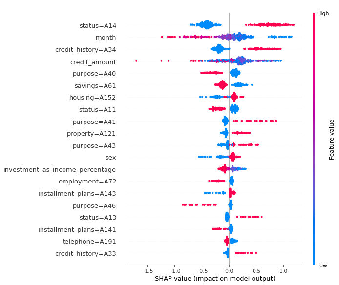

```python
"""
A14 : no checking account (Status of existing checking account)
A191 : no telephone
"""

# summarize the effects of all the features
shap.summary_plot(shap_values, X_test)
```

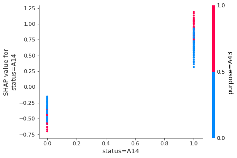

```python
"""
status = no checking account
purpose = radio/television
"""
# whole dataset dependance plot
# strongest interaction with key is shown for dispersion
shap.dependence_plot("status=A14", shap_values, X_test)
```

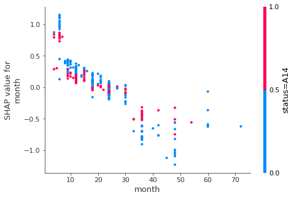

```python
"""
status A14 = no checking account
"""
# whole dataset dependance plot
# strongest interaction with key is shown for dispersion
shap.dependence_plot("month", shap_values, X_test)
```

National Health and Nutrition Examination Survey showing mortality-sex interaction

[figure not shown]

It also works for tensorflow/keras/pytorch.

Using `DeepLIFT` to interpret a model with respect to many instances

[figure not shown]

Using `GradientExplainer` you can explain a layer with respect to many instances

[figure not shown]

For deep neural network specific model interpretation the [Distill Project](https://distill.pub/) has some great interactive resources.

There are also libraries like keras-vis.

Using keras-vis for convolutional filter visualization via Activation Maximization.

[figure not shown]

Using keras-vis for attention visualization.

[figure not shown]

# Ethics in AI

## Fairness

There are dozens of conflicting definitions of fairness.

[figure not shown]

People are biased, we create biased datasets and ML models cheat.

From [white-first facial recognition](http://proceedings.mlr.press/v81/buolamwini18a/buolamwini18a.pdf),

to [male-first word embeddings](https://arxiv.org/abs/1803.09797)

models which do not protect against these issues will behave unfairly.

AI is now used in many high-stakes decision making applications

[figure not shown]

Stolen from IBM, AI Fairness 360</small>

Fixing ML so that it does not exacerbate these issues requires effort on the part of developers

But there are tools for that!

[figure not shown]

| Name | Description | Link |
| --- | --- | --- |
| Fairness Measures | Framework to test given algorithm on variety of datasets and fairness metrics | https://github.com/megantosh/fairness_measures_code |
| Fairness Comparison | Extensible test-bed to facilitate direct comparisons of algorithms with respect to fairness measures. Includes raw & preprocessed datasets | https://github.com/algofairness/fairnesscomparison |
| Themis-ML | Python library built on scikit-learn that implements fairness-aware machine learning algorithms | https://github.com/cosmicBboy/themis-ml |
| FairML | Looks at significance of model inputs to quantify prediction dependence on inputs | https://github.com/adebayoj/fairml |
| Aequitas | Web audit tool as well as python lib. Generates bias report for given model and dataset | https://github.com/dssg/aequitas |
| Fairtest | Tests for associations between algorithm outputs and protected populations | https://github.com/columbia/fairtest |
| Themis | Takes a black-box decision-making procedure and designs test cases automatically to explore where the procedure might be exhibiting group-based or causal discrimination | https://github.com/LASER-UMASS/Themis |
| Audit-AI | Python library built on top of scikit-learn with various statistical tests for classification and regression tasks | https://github.com/pymetrics/audit-ai |
| AIF360 | Comprehensive set of metrics for datasets and models to test for biases, explanations for these metrics, and algorithms to mitigate bias in datasets and models | https://github.com/IBM/AIF360 |

<sub><sub><sub><sub>[Stolen from IBM, AI Fairness 360](http://cognitive-science.info/wp-content/uploads/2018/09/CSIG_krv-aif360-2018-09-20-1.pdf)</sub></sub></sub></sub></sub></sub></sub>

There are also several classes, books, workshops, conferences, etc on the topic

https://fairmlclass.github.io

https://fairmlbook.org

https://mrtz.org/nips17/#/

Your data is probably bad

<sub><sup><sub><sup>It'll probably have skewed samples, tainted samples, limited features, sample size disparity, proxies, etc</sup></sub></sup></sub></sup></sub>

If you can measure how bad and fix the data while your model performs well, that's a good start but you'll still miss biases

Your model is probably also bad

<sub><sup><sub><sup>It was definitely trained on bad data that you'll only find out about later</sup></sub></sup></sub></sup></sub>

[Weight your samples or use a loss function which can compensate, then modify the output to allow for equal treatment.](https://towardsdatascience.com/a-tutorial-on-fairness-in-machine-learning-3ff8ba1040cb)

but your model may suffer loss of accuracy

Having done due diligence in removing bias, if possible provide documentation about what steps were taken in the form of [model cards](https://arxiv.org/abs/1810.03993) or [datasheets](https://arxiv.org/abs/1803.09010).

Providing good data [providence and reproduceability](https://news.ycombinator.com/item?id=17242053) methods have been used, later investigations can help remove bias.

Model development is an iterative process which benefits from good design. Like any product you should experiment quickly and involve your users to uncover issues while they are more easily mitigated.

## Trust

People will trust AI more than you expect

[figure not shown]

[source](https://www.engadget.com/2016/02/29/humans-trust-this-emergency-robot-more-than-common-sense/)

But they will also trust it less than you need them to.

To balance the dichotomy of trust, make your models [trustworthy](https://twimlai.com/twiml-talk-212-making-algorithms-trustworthy-with-david-speigelhalter/)

You can [increase people's trust in your models](https://arxiv.org/abs/1808.07261) by providing:

- fairness
- robustness
- explainability
- lineage

## Privacy

Canada's [PIPEDA](https://www.priv.gc.ca/en/privacy-topics/privacy-laws-in-canada/the-personal-information-protection-and-electronic-documents-act-pipeda/) and Europe's [GDPR](https://eur-lex.europa.eu/legal-content/EN/TXT/?qid=1528874672298&uri=CELEX%3A32016R0679) protect user data

You may be building models from this data

Deep learning models can be fooled by adversarial attacks), and also attacked to extract information.

In Homogeneity Attacks<sup>[1](https://en.wikipedia.org/wiki/L-diversity)</sup> sensitive values can be extracted by leveraging similarity

In Background Knowledge Attacks <sup>[2](https://dl.acm.org/citation.cfm?doid=1217299.1217302)</sup> associations are used reduce the set of possible values for the sensitive attribute

Models may contain PII and if so may need to be retrained to remove such data.

[figure not shown]

## Designing with AI in mind

Donald Norman, author of "The Design of Everyday Things" suggests designing to these principles:

- **visibility** - what you see
- **affordance** - cues for interaction
- **mapping** - connecting control and effect
- **feedback** - response to interaction
- **constraints** - what you can't do
- **consistancy** - helping users learn from patterns

These still apply to ML.

## Human-Centered Machine Learning

[Shamelessly stolen from Jess Holbrook](https://medium.com/google-design/human-centered-machine-learning-a770d10562cd)

#### Don’t expect Machine learning to figure out what problems to solve

"if you aren’t aligned with a human need, you’re just going to build a very powerful system to address a very small — or perhaps nonexistent — problem."

[figure not shown]

#### Ask yourself if ML will address the problem in a unique way

The task below can be solved with `contains keyword`

[figure not shown]

Describe the way a theoretical human “expert” might perform the task today.

If your human expert were to perform this task, how would you respond to them so they improved for the next time? Do this for all four phases of the confusion matrix.

If a human were to perform this task, what assumptions would the user want them to make?

#### Fake it with personal examples and wizards

Conduct [Wizard of Oz experiments](https://en.wikipedia.org/wiki/Wizard_of_Oz_experiment) where the AI is replaced with humans until its purpose is concrete.

[figure not shown]

#### Weigh the costs of false positives and false negatives

How users may view a confusion matrix.

[figure not shown]

The 4 corners of the 'confusion matrix' will have different presentations and impacts on your users, but can usually be traded off.

If you cannot tolerate a missed crime, maybe you can tolerate a misfired warning.

If a misfired warning is bad, by using explainability and usability testing you might mitigate the negative impact.

#### Plan for 'Human in the loop' and adaptation

Your users may form inaccurate understandings of your models.

[figure not shown]

Collect their feedback and allow it to improve the model

[figure not shown]

You will learn as your models learn.

[figure not shown]

#### Teach your algorithm using the right labels

Labels can't be collected until you know what you need.

And you don't know what you need until you've trained a model.

Allow for 'truthiness' in labeling and plan to spend some time iterating on your labels

## FIN

<sub>Any questions?</sub>